# Assignment 9

1. Using the dataset from last week, test a model that postulates that threat mediates the relationship between empathy and prejudice (see the scripts from the last two weeks to determine which indicators define those variables).

Install packages:

```r
library(pacman)
p_load(semPlot, tidyverse, lavaan, psych, kableExtra)
```

Load data:

```r
data <- read.delim("../assignment_9/data/Northdale survey _reverse coded_.dat")
```

Convert the variables:

```r
#   Threat
    data$Thrt_Phy1<-data$Thrt_Phy1/3
    data$Thrt_Phy2<-data$Thrt_Phy2/3
    data$Thrt_Phy3<-data$Thrt_Phy3/3
#   Prejudice
    data$Att_IS1<-(data$Att_IS1-1)/6.75
    data$Att_IS2<-(data$Att_IS2-1)/6.75
    data$Att_IS4<-(data$Att_IS4-1)/6.75
#   Contact quantity
    data$Cnt_pos_B<-data$Cnt_pos_B/2
    data$Cnt_pos_IS1<-data$Cnt_pos_IS1/2
#   Contact_quality
    data$Cnt_Qul_IS1<-data$Cnt_Qul_IS1/3
    data$Cnt_Qul_IS2<-data$Cnt_Qul_IS2/3
    data$Cnt_Qul_IS3<-data$Cnt_Qul_IS3/3
#   Empathy
    data$Empath1<-data$Empath1/3
    data$Empath2<-data$Empath2/3
    data$Empath3<-data$Empath3/3
```

```r
path.dat <- data
```

Test the model:

```r
#   SEM of model1
    pathm1 <- '
            # MEASUREMENT MODEL
              threat_scale       =~ Thrt_Phy1 + Thrt_Phy2 + Thrt_Phy3
              prejudice_scale    =~ Att_IS1 + Att_IS2 + Att_IS4
              empathy_scale      =~ Empath1 + Empath2 + Empath3

            # STRUCTURAL MODEL
              threat_scale ~ empathy_scale
              prejudice_scale ~ threat_scale + empathy_scale
'
```

```r
prejpathfit1 <- sem(pathm1, data = path.dat)
    summary(prejpathfit1 , fit.measures = T, standardized = T)
```

```
lavaan 0.6-3 ended normally after 61 iterations

  Optimization method                           NLMINB
  Number of free parameters                         21

                                                  Used       Total
  Number of observations                           293         364

  Estimator                                         ML
  Model Fit Test Statistic                      28.007
  Degrees of freedom                                24
  P-value (Chi-square)                           0.260

Model test baseline model:

  Minimum Function Test Statistic             1382.625
  Degrees of freedom                                36
  P-value                                        0.000

User model versus baseline model:

  Comparative Fit Index (CFI)                    0.997
  Tucker-Lewis Index (TLI)                       0.996

Loglikelihood and Information Criteria:

  Loglikelihood user model (H0)               -196.406
  Loglikelihood unrestricted model (H1)       -182.402

  Number of free parameters                         21
  Akaike (AIC)                                 434.812
  Bayesian (BIC)                               512.095
  Sample-size adjusted Bayesian (BIC)          445.499

Root Mean Square Error of Approximation:

  RMSEA                                          0.024
  90 Percent Confidence Interval          0.000  0.055
  P-value RMSEA <= 0.05                          0.906

```

[output cut: 32 more lines]

```

Variances:
                   Estimate  Std.Err  z-value  P(>|z|)   Std.lv  Std.all
   .Thrt_Phy1         0.020    0.002    9.299    0.000    0.020    0.274
   .Thrt_Phy2         0.014    0.003    5.119    0.000    0.014    0.127
   .Thrt_Phy3         0.022    0.003    8.104    0.000    0.022    0.220
   .Att_IS1           0.040    0.007    5.406    0.000    0.040    0.292
   .Att_IS2           0.049    0.008    6.282    0.000    0.049    0.335
   .Att_IS4           0.091    0.009   10.609    0.000    0.091    0.621
   .Empath1           0.053    0.005   10.494    0.000    0.053    0.553
   .Empath2           0.035    0.005    6.512    0.000    0.035    0.308
   .Empath3           0.027    0.006    4.601    0.000    0.027    0.222
   .threat_scale      0.054    0.006    8.889    0.000    0.997    0.997
   .prejudice_scal    0.080    0.011    7.379    0.000    0.835    0.835
    empathy_scale     0.042    0.007    6.063    0.000    1.000    1.000
```

The model that suggests that empathy predicts prejucdice, both directly and through the mediator variable threat, is not significantly different from the saturated model (p = 0.26, df = 24). This means that it is not significantly different from the model that utilises all possible paths, despite it being simpler - a good indicator of parsimony. The model (model 1) is significantly different from the null model (p < 0.001, df = 36), indicating that we have not dropped too many potential paths, and our predictions are still better than the no-information rate. CFI and TLI - measures of our model’s location on the continuum from saturated to null model - indicate that our model is far closer to the saturated model. THese measures should approximate 1, and values > 0.95 indicate a good fit. By these measures our model has a good fit (CFI = 1.00, TLI = 1.00). AIC and BIC are noted for comparison with other models. RMSEA value should approximate 0, and values < 0.05 indicate a good fit. By this measure our model has a good fit, with the upper end of the CI only slightly above optimal (RMSEA = 0.02, CI = 0.00 - 0.06). SRMR should approximate 0, and values < 0.05 indicate a good fit. This measure also indicates that our model has good fit (SRMR = 0.03).

An analysis of our latent variables indicates that all manifest variables significantly load onto the proposed latent variables.

Our regression analysis indicates that empathy does not significantly predict threat (beta = 0.05, p = 0.42). However, threat and empathy are both significant direct predictors of prejudice (empathy: beta = -0.24, p < 0.001; threat: beta = 0.34, p < 0.001). Increased empathy leads to decreased prejudice, and increased threat leads to increased prejuice (this second relationship is stronger).

Next, we draw the model:

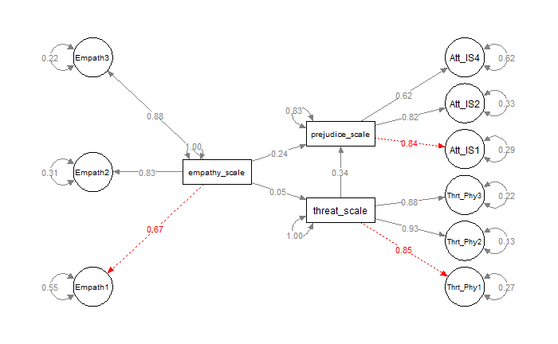

```r
semPaths(prejpathfit1, whatLabels = "std", residuals = TRUE, nCharNodes = 15, sizeMan = 8, shapeMan = "circle", shapeLat = "rectangle", sizeLat = 14, sizeLat2 = 5, edge.label.cex = .8, layout = "tree", rotation = 2, fixedStyle = c("red", 3), optimizeLatRes = T)
```

Next, we consider the residuals and modification indices:

```r
resid(prejpathfit1 , type = "normalized")
```

```
$`type`
[1] "normalized"

$cov
          Thr_P1 Thr_P2 Thr_P3 At_IS1 At_IS2 At_IS4 Empth1 Empth2 Empth3
Thrt_Phy1  0.000
Thrt_Phy2  0.023  0.000
Thrt_Phy3 -0.064  0.009  0.000
Att_IS1    0.466 -0.267  0.217  0.000
Att_IS2   -0.238 -0.445  0.243  0.037  0.000
Att_IS4    0.201  0.494  0.536 -0.110  0.014  0.000
Empath1    2.058  0.924  1.199  0.252  0.003 -0.615  0.000
Empath2   -0.175 -0.476 -0.405 -0.574 -0.280 -0.656 -0.117  0.000
Empath3    0.088 -0.624  0.662  0.303  0.569 -0.251  0.042  0.015  0.000
```

```r
modificationindices(prejpathfit1, sort = T)
```

|  | lhs | op | rhs | mi | epc | sepc.lv | sepc.all | sepc.nox |
| --- | --- | --- | --- | --- | --- | --- | --- | --- |
| 63 | Thrt_Phy3 | ~~ | Empath3 | 9.027 | 0.007 | 0.007 | 0.276 | 0.276 |
| 57 | Thrt_Phy2 | ~~ | Empath3 | 6.557 | -0.006 | -0.006 | -0.285 | -0.285 |
| 48 | Thrt_Phy1 | ~~ | Empath1 | 5.611 | 0.005 | 0.005 | 0.162 | 0.162 |
| 28 | threat_scale | =~ | Empath1 | 3.640 | 0.122 | 0.028 | 0.092 | 0.092 |
| 62 | Thrt_Phy3 | ~~ | Empath2 | 3.584 | -0.004 | -0.004 | -0.152 | -0.152 |
| 44 | Thrt_Phy1 | ~~ | Thrt_Phy3 | 2.909 | -0.011 | -0.011 | -0.519 | -0.519 |
| 45 | Thrt_Phy1 | ~~ | Att_IS1 | 2.876 | 0.004 | 0.004 | 0.141 | 0.141 |
| 56 | Thrt_Phy2 | ~~ | Empath2 | 2.628 | 0.003 | 0.003 | 0.158 | 0.158 |
| 38 | empathy_scale | =~ | Thrt_Phy2 | 2.201 | -0.078 | -0.016 | -0.048 | -0.048 |
| 76 | Empath1 | ~~ | Empath2 | 2.105 | -0.016 | -0.016 | -0.381 | -0.381 |

[output cut: 44 more lines]

## The residuals are all fairly low, indicating a good fit. The only problematic item appears to be “Empath1” (an indicator pf empathy). It correlates much more with Thr_P1 (a measure of threat) than our model suggests. This indicates that there may be a problem with the measurement model, although it is fairly contained. The modification indices confirm that we could improve this model by altering our measurement model. The biggest effects can be obtained by allowing the errors to covary between items on the threat and empathy scales, and by redefining “Empath1” as part of the threat scale. This suggests that both scales may be measuring highly related concepts. No new paths are suggested by the modification indices, so we leave our model as is. As the hypothesis is that threat mediates the relationship between empathy and prejudice, it would not make sense to allow the errors to covary for the two scales.

Tabulate the direct, indirect and total effects of empathy on prejudice, and provide significance tests where appropriate. See whether you can compute the p values using normal theory and bootstrapping.

```r
#   SEM of model1 (direct and indirect effects)
    pathm1_effects <- '
            # MEASUREMENT MODEL
              threat_scale       =~ Thrt_Phy1 + Thrt_Phy2 + Thrt_Phy3
              prejudice_scale    =~ Att_IS1 + Att_IS2 + Att_IS4
              empathy_scale      =~ Empath1 + Empath2 + Empath3

          # direct effect
             prejudice_scale ~ c*empathy_scale

          # mediator
             threat_scale ~ a*empathy_scale
             prejudice_scale ~ b*threat_scale

          # indirect effect (a*b)
             ab := a*b

          # total effect
             total := c + (a*b)
         '
prejpathfit1_effects <- sem(pathm1_effects, data = path.dat)
summary(prejpathfit1_effects , fit.measures = T, standardized = T)
```

```
lavaan 0.6-3 ended normally after 61 iterations

  Optimization method                           NLMINB
  Number of free parameters                         21

                                                  Used       Total
  Number of observations                           293         364

  Estimator                                         ML
  Model Fit Test Statistic                      28.007
  Degrees of freedom                                24
  P-value (Chi-square)                           0.260

Model test baseline model:

  Minimum Function Test Statistic             1382.625
  Degrees of freedom                                36
  P-value                                        0.000

User model versus baseline model:

  Comparative Fit Index (CFI)                    0.997
  Tucker-Lewis Index (TLI)                       0.996

Loglikelihood and Information Criteria:

  Loglikelihood user model (H0)               -196.406
  Loglikelihood unrestricted model (H1)       -182.402

  Number of free parameters                         21
  Akaike (AIC)                                 434.812
  Bayesian (BIC)                               512.095
  Sample-size adjusted Bayesian (BIC)          445.499

Root Mean Square Error of Approximation:

  RMSEA                                          0.024
  90 Percent Confidence Interval          0.000  0.055
  P-value RMSEA <= 0.05                          0.906

```

[output cut: 38 more lines]

```
   .Thrt_Phy3         0.022    0.003    8.104    0.000    0.022    0.220
   .Att_IS1           0.040    0.007    5.406    0.000    0.040    0.292
   .Att_IS2           0.049    0.008    6.282    0.000    0.049    0.335
   .Att_IS4           0.091    0.009   10.609    0.000    0.091    0.621
   .Empath1           0.053    0.005   10.494    0.000    0.053    0.553
   .Empath2           0.035    0.005    6.512    0.000    0.035    0.308
   .Empath3           0.027    0.006    4.601    0.000    0.027    0.222
   .threat_scale      0.054    0.006    8.889    0.000    0.997    0.997
   .prejudice_scal    0.080    0.011    7.379    0.000    0.835    0.835
    empathy_scale     0.042    0.007    6.063    0.000    1.000    1.000

Defined Parameters:
                   Estimate  Std.Err  z-value  P(>|z|)   Std.lv  Std.all
    ab                0.027    0.034    0.798    0.425    0.018    0.018
    total            -0.340    0.105   -3.238    0.001   -0.226   -0.226
```

```r
colnames <- c("Value", "Direct effect", "Indirect effect", "Total effect")
betavalues <- c("std.all", -0.24, 0.02, -0.23)
pvalues <- c("p (>|z|)", 0.000, 0.425, 0.001)
effects_tab <- rbind(colnames, betavalues, pvalues)
```

```r
effects_tab %>%
  kable(digits = 4) %>%
  kable_styling()
```

| colnames | Value | Direct effect | Indirect effect | Total effect |
| --- | --- | --- | --- | --- |
| betavalues | std.all | -0.24 | 0.02 | -0.23 |
| pvalues | p (>\|z\|) | 0 | 0.425 | 0.001 |

## The direct effect of empathy on prejucdice is significant (beta = -0.24, p < 0.001). However the indirect effect through the mediating variable threat is small and insignificant (beta = 0.02, p = 0.425). The total effect is significant (beta = -0.23, p = 0.001), although slightly less than the direct effect alone. For this reason, threat is not a useful mediator between empathy and prejudice.

2. Compare an SEM model that proposes that Contact_quantity has direct and indirect effects on prejudice through threat, against a model that proposes that contact quality is a prior determinant of contact quantity and itself has direct and indirect effects on prejudice through both contact quantity and threat. Are there grounds for preferring either model over the other?

Model 2: contact quantity predicts prejudice

```r
#   SEM of model2
    pathm2 <- '
            # MEASUREMENT MODEL
              threat_scale       =~ Thrt_Phy1 + Thrt_Phy2 + Thrt_Phy3
              prejudice_scale    =~ Att_IS1 + Att_IS2 + Att_IS4
              contact_quant      =~ Cnt_pos_B + Cnt_pos_IS1

            # direct effect
             prejudice_scale ~ c*contact_quant

            # mediator
             threat_scale ~ a*contact_quant
             prejudice_scale ~ b*threat_scale

            # indirect effect (a*b)
             ab := a*b

            # total effect
             total := c + (a*b)
'
```

```r
prejpathfit2 <- sem(pathm2, data = path.dat)
    summary(prejpathfit2 , fit.measures = T, standardized = T)
```

```
lavaan 0.6-3 ended normally after 53 iterations

  Optimization method                           NLMINB
  Number of free parameters                         19

                                                  Used       Total
  Number of observations                           292         364

  Estimator                                         ML
  Model Fit Test Statistic                      15.269
  Degrees of freedom                                17
  P-value (Chi-square)                           0.576

Model test baseline model:

  Minimum Function Test Statistic             1124.848
  Degrees of freedom                                28
  P-value                                        0.000

User model versus baseline model:

  Comparative Fit Index (CFI)                    1.000
  Tucker-Lewis Index (TLI)                       1.003

Loglikelihood and Information Criteria:

  Loglikelihood user model (H0)               -453.861
  Loglikelihood unrestricted model (H1)       -446.227

  Number of free parameters                         19
  Akaike (AIC)                                 945.723
  Bayesian (BIC)                              1015.581
  Sample-size adjusted Bayesian (BIC)          955.327

Root Mean Square Error of Approximation:

  RMSEA                                          0.000
  90 Percent Confidence Interval          0.000  0.048
  P-value RMSEA <= 0.05                          0.961

```

[output cut: 36 more lines]

```
   .Thrt_Phy2         0.014    0.003    5.492    0.000    0.014    0.134
   .Thrt_Phy3         0.020    0.003    7.886    0.000    0.020    0.208
   .Att_IS1           0.036    0.007    5.004    0.000    0.036    0.258
   .Att_IS2           0.049    0.007    6.536    0.000    0.049    0.331
   .Att_IS4           0.092    0.009   10.693    0.000    0.092    0.617
   .Cnt_pos_B         0.114    0.026    4.381    0.000    0.114    0.462
   .Cnt_pos_IS1       0.141    0.021    6.652    0.000    0.141    0.593
   .threat_scale      0.048    0.006    8.633    0.000    0.908    0.908
   .prejudice_scal    0.079    0.011    7.192    0.000    0.765    0.765
    contact_quant     0.133    0.030    4.385    0.000    1.000    1.000

Defined Parameters:
                   Estimate  Std.Err  z-value  P(>|z|)   Std.lv  Std.all
    ab               -0.044    0.020   -2.264    0.024   -0.050   -0.050
    total            -0.403    0.085   -4.746    0.000   -0.458   -0.458
```

The model that suggests that contact quantity predicts prejudice, both directly and through the mediator variable threat, is not significantly different from the saturated model (p = 0.58, df = 17). This means that it is not significantly different from the model that utilises all possible paths, despite it being simpler - a good indicator of parsimony. The model (model 2) is significantly different from the null model (p < 0.001, df = 28), indicating that we have not dropped too many potential paths, and our predictions are still better than the no-information rate. CFI and TLI - measures of our model’s location on the continuum from saturated to null model - indicate that our model is far closer to the saturated model. THese measures should approximate 1, and values > 0.95 indicate a good fit. By these measures our model has a good fit (CFI = 1.00, TLI = 1.00). AIC and BIC are noted for comparison with other models. RMSEA value should approximate 0, and values < 0.05 indicate a good fit. By this measure our model has a good fit, with the upper end of the CI within the optimal range (RMSEA = 0.00, CI = 0.00 - 0.05). SRMR should approximate 0, and values < 0.05 indicate a good fit. This measure also indicates that our model has good fit (SRMR = 0.03).

An analysis of our latent variables indicates that all manifest variables significantly load onto the proposed latent variables.

Our regression analysis indicates that contact quantity significantly predicts threat (beta = -0.30, p < 0.001), and prejudice can be significantly predicted by both contact quantity (beta = -0.41, p = < 0.001), and (to a lesser degree) threat (beta = 0.17, p = 0.02).The mediation (indirect effect of contact quantity on prejudice through the mediator threat) is significant, but small (beta = -0.05, p = 0.02). The total effect of contact quantity on prejudice (combined direct and indirect effects) is significant (beta = -0.46, p < 0.001). Thus an increase in contact quantity leads to a decrease in prejudice, as well as a decrease in threat, which in turn leads to a further decrease in prejudice.

Next, we look at the proposed model visually:

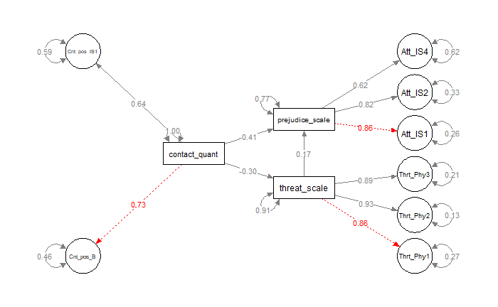

```r
semPaths(prejpathfit2, whatLabels = "std", residuals = TRUE, nCharNodes = 15, sizeMan = 8, shapeMan = "circle", shapeLat = "rectangle", sizeLat = 14, sizeLat2 = 5, edge.label.cex = .8, layout = "tree", rotation = 2, fixedStyle = c("red", 3), optimizeLatRes = T)
```

Next, we inspect the residuals and modification indices:

```r
resid(prejpathfit2 , type = "normalized")
```

```
$`type`
[1] "normalized"

$cov
            Thr_P1 Thr_P2 Thr_P3 At_IS1 At_IS2 At_IS4 Cnt__B C__IS1
Thrt_Phy1    0.000
Thrt_Phy2    0.020  0.000
Thrt_Phy3   -0.016 -0.007  0.000
Att_IS1      0.352 -0.098  0.492  0.000
Att_IS2     -0.328 -0.576  0.178  0.066  0.000
Att_IS4     -0.077  0.157  0.255 -0.076 -0.135  0.000
Cnt_pos_B    0.225 -0.059 -0.521  0.534 -0.045 -1.208  0.000
Cnt_pos_IS1  0.737 -0.141  0.348  0.063  0.265 -1.515  0.000  0.000
```

```r
modificationindices(prejpathfit2, sort = T)
```

|  | lhs | op | rhs | mi | epc | sepc.lv | sepc.all | sepc.nox |
| --- | --- | --- | --- | --- | --- | --- | --- | --- |
| 40 | contact_quant | =~ | Att_IS4 | 5.575 | -0.181 | -0.066 | -0.172 | -0.172 |
| 59 | Att_IS1 | ~~ | Att_IS2 | 3.974 | 0.035 | 0.035 | 0.847 | 0.847 |
| 53 | Thrt_Phy2 | ~~ | Cnt_pos_IS1 | 2.895 | -0.007 | -0.007 | -0.155 | -0.155 |
| 61 | Att_IS1 | ~~ | Cnt_pos_B | 2.338 | 0.011 | 0.011 | 0.164 | 0.164 |
| 67 | Att_IS4 | ~~ | Cnt_pos_IS1 | 2.288 | -0.012 | -0.012 | -0.106 | -0.106 |
| 38 | contact_quant | =~ | Att_IS1 | 1.727 | 0.094 | 0.034 | 0.092 | 0.092 |
| 57 | Thrt_Phy3 | ~~ | Cnt_pos_B | 1.540 | -0.005 | -0.005 | -0.108 | -0.108 |
| 58 | Thrt_Phy3 | ~~ | Cnt_pos_IS1 | 1.341 | 0.005 | 0.005 | 0.090 | 0.090 |
| 32 | prejudice_scale | =~ | Thrt_Phy3 | 1.231 | 0.040 | 0.013 | 0.041 | 0.041 |
| 66 | Att_IS4 | ~~ | Cnt_pos_B | 1.187 | -0.009 | -0.009 | -0.086 | -0.086 |

[output cut: 33 more lines]

The residuals are all low - indicating a good fit between our observed and expected covariances. The modification indices only offer very minor modifications to the chi-square value, indicating that no further manipulation could make a large improvement on our model. Furthermore, no additional paths are suggested - the modification indices are limited to suggestions on how to redefine our measurement model.

[output not shown]

Next, we look at the proposed model visually:

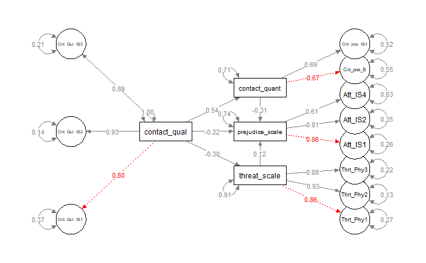

```r
semPaths(prejpathfit3, whatLabels = "std", residuals = TRUE, nCharNodes = 15, sizeMan = 8, shapeMan = "circle", shapeLat = "rectangle", sizeLat = 14, sizeLat2 = 5, edge.label.cex = .8, layout = "tree", rotation = 2, fixedStyle = c("red", 3), optimizeLatRes = T)
```

Next we consider the residuals:

```r
resid(prejpathfit3 , type = "normalized")
```

```
$`type`
[1] "normalized"

$cov
            Thr_P1 Thr_P2 Thr_P3 At_IS1 At_IS2 At_IS4 Cnt__B C__IS1 C_Q_IS1 C_Q_IS2
Thrt_Phy1    0.000
Thrt_Phy2   -0.014  0.000
Thrt_Phy3   -0.008  0.014  0.000
Att_IS1      0.539  0.199  0.789  0.041
Att_IS2     -0.136 -0.274  0.481  0.093  0.036
Att_IS4     -0.021  0.304  0.378 -0.023 -0.060  0.021
Cnt_pos_B   -1.159 -1.661 -2.041  0.091 -0.511 -1.517  0.000
Cnt_pos_IS1 -0.207 -1.221 -0.656  0.275  0.425 -1.288  0.000  0.000
Cnt_Qul_IS1 -0.244  0.466  0.991  0.002 -0.286  0.342 -0.248  0.112  0.000
Cnt_Qul_IS2 -0.380 -0.165  0.708  0.194  0.049 -0.028 -0.084 -0.088  0.042   0.000
Cnt_Qul_IS3 -0.662 -0.014  0.207 -0.324  0.193 -0.072 -0.247  0.357 -0.036  -0.002
            C_Q_IS3
Thrt_Phy1
Thrt_Phy2
Thrt_Phy3
Att_IS1
Att_IS2
Att_IS4
Cnt_pos_B
Cnt_pos_IS1
Cnt_Qul_IS1
Cnt_Qul_IS2
Cnt_Qul_IS3  0.000
```

```r
modificationindices(prejpathfit3, sort = T)
```

|  | lhs | op | rhs | mi | epc | sepc.lv | sepc.all | sepc.nox |
| --- | --- | --- | --- | --- | --- | --- | --- | --- |
| 56 | contact_quant | =~ | Att_IS4 | 4.349 | -0.174 | -0.059 | -0.153 | -0.153 |
| 90 | Thrt_Phy3 | ~~ | Cnt_pos_B | 3.552 | -0.008 | -0.008 | -0.151 | -0.151 |
| 131 | threat_scale | ~ | prejudice_scale | 3.352 | 0.398 | 0.561 | 0.561 | 0.561 |
| 132 | threat_scale | ~ | contact_quant | 3.352 | -0.118 | -0.175 | -0.175 | -0.175 |
| 124 | threat_scale | ~~ | contact_quant | 3.352 | -0.010 | -0.155 | -0.155 | -0.155 |
| 130 | contact_quant | ~ | threat_scale | 3.352 | -0.203 | -0.137 | -0.137 | -0.137 |
| 129 | contact_quant | ~ | prejudice_scale | 3.352 | -1.176 | -1.117 | -1.117 | -1.117 |
| 93 | Thrt_Phy3 | ~~ | Cnt_Qul_IS2 | 3.351 | 0.003 | 0.003 | 0.173 | 0.173 |
| 83 | Thrt_Phy2 | ~~ | Cnt_pos_IS1 | 3.313 | -0.007 | -0.007 | -0.175 | -0.175 |
| 85 | Thrt_Phy2 | ~~ | Cnt_Qul_IS2 | 3.306 | -0.003 | -0.003 | -0.203 | -0.203 |

[output cut: 82 more lines]